# Descripción del Proyecto

#### Principales géneros para cada región

```python
def genero_region(region):
    g1=(data_actual
        .pivot_table(index='Genre', values=(region), aggfunc='sum')
        .sort_values(by=region, ascending=False)
        .head(5)  )

    g1.plot(kind='bar', ylabel='Ventas (milllones USD)', grid=True, figsize=(15,4))
    plt.title(f"Ventas en {region[:2]}", fontsize=30)
```

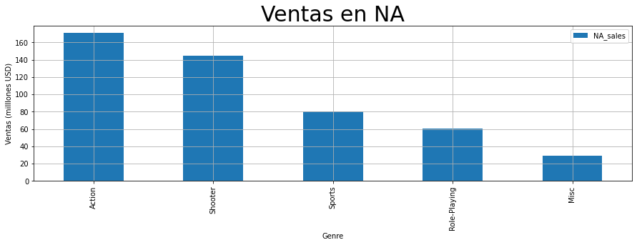

```python
genero_region('NA_sales')
```

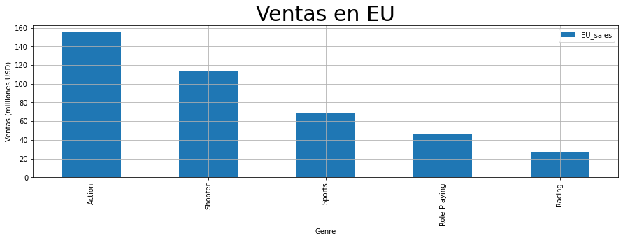

```python
genero_region('EU_sales')
```

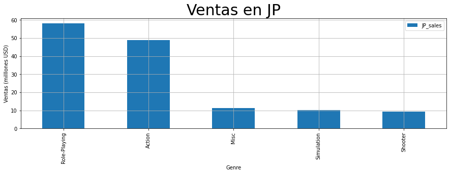

```python
genero_region('JP_sales')
```

Los mercados de norteamerica (NA) y Europa (EU) son practicamente identicos respecto a los géneros mas populares. solo una leve diferencia es que en NA que el quinto género mas popular es "Misc" mientras que en EU es "Racing".

En el mercado japones (JP) los géneros populares son diferentes. El género "Role-Playing" es el mas popular seguido por el género "Action".

Para las 3 regiones, los géneros en común son "Action" y "Shotter", pero en japón estos son menos relevantes que en NA y EU.

### Influencia de la clasificacion ESRB

A cotinuación veremos de que forma la clasificación de edad (ESRB) afecta a la venta de los juegos. Para el analisis, se procederá a descartar los juegos cuya clasificaión des deconocida (Unknown).

```python
def esrb_region(region):
    g1=(data_actual
        .query('Rating!="Unknown"')
        .pivot_table(index='Rating', values=(region), aggfunc='sum')
        .sort_values(by=region, ascending=False) )
    g1.plot(kind='bar', ylabel='Ventas (milllones USD)', grid=True, figsize=(15,4))
    plt.title(f"Ventas por ESRB en {region[:2]}", fontsize=30)
```

[figure not shown]

```python
esrb_region('NA_sales')
```

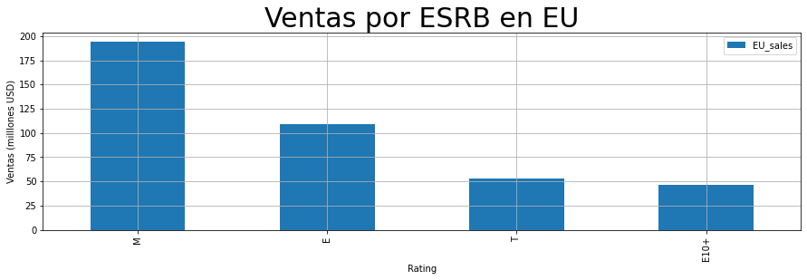

```python
esrb_region('EU_sales')
```

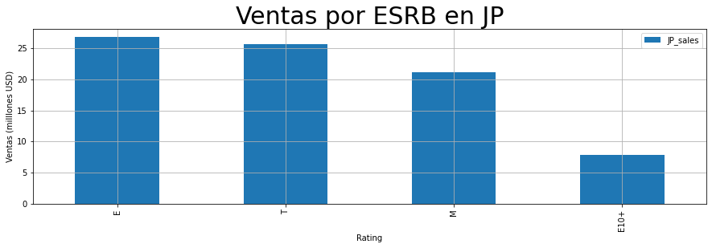

```python
esrb_region('JP_sales')
```

En Norteamerica (NA) y Europa (EU) las principales ventas provienen de juegos clasificación M (Mature), seguidos de E (Everyone), T (Teen) y E10+ (Everyone +10).

Por otro lado, en Japón (JP) las principales ventas provienes de juegos clásificaciones E (Everyone), seguido por T (Teen), M (Mature) y E10+ (Everyone +10).

### Verificación de las hipótesis

#### Calificaciones promedio entre Xbox One y PC

A continuaciones probaremos la hipótesis que **las calificaciones promedio de los usuarios para las plataformas Xbox One y PC son las mismas.**

Para esto, planteamos nuestras hipostesis nula y alterna y verificamos la hipotesis nula.  
-La hipotesis nula es que las calificaciones promedio de las plataformas Xbox One y PC son iguales  
-La hipotesis alterna es que las calificaiones promedio de las plataformas Xbox One y PC son diferentes.

Estamos ante la verificación de una **hipótesis sobre la igualdad de las medias de dos poblaciones**, para probar la hipótesis de que las medias de dos poblaciones estadísticas son iguales según las muestras tomadas de ellas, es necesario aplicar el método scipy.stats.ttest_ind.

Para el cálculo de esta hipotesis, usaré un valor de significación (alpha) de un 5%. Es decir, si el valor-p obtenido en el análisis estadístico es menor que 0.05, se considerará que el resultado es estadísticamente significativo y se rechazará la hipótesis nula en favor de la hipótesis alterna.

El promedio de las calificaciones de XOne es: 6.5

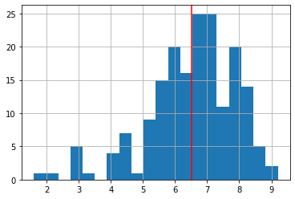

```python
#aux=data_actual.query('Platform=="XOne" and User_Score>-1')['User_Score'].mean()
aux=data_actual.query('Platform=="XOne"')['User_Score'].mean()
print_mejorado(f"El promedio de las calificaciones de XOne es: {aux:.2}",20)
#data_actual.query('Platform=="XOne" and User_Score>-1')['User_Score'].hist(bins=20)
data_actual.query('Platform=="XOne"')['User_Score'].hist(bins=20)
plt.axvline(x=aux, color='r')
```

El promedio de las calificaciones de PC es: 6.4

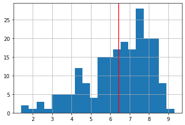

```python
#aux=data_actual.query('Platform=="PC" and User_Score>-1')['User_Score'].mean()
aux=data_actual.query('Platform=="PC"')['User_Score'].mean()
print_mejorado(f"El promedio de las calificaciones de PC es: {aux:.2}",20)

#data_actual.query('Platform=="PC" and User_Score>-1')['User_Score'].hist(bins=20)
data_actual.query('Platform=="PC"')['User_Score'].hist(bins=20)
plt.axvline(x=aux, color='r')
```

Ambas distribuciones parecen tener un sesgo hacia la izquierda.

Definimos nuestros muestras:

```python
calificaciones_xone = data_actual.query('Platform=="XOne" and User_Score.notnull()')['User_Score']
calificaciones_pc = data_actual.query('Platform=="PC" and User_Score.notnull()')['User_Score']
```

Aplicamos el test de Shapiro para evaluar la normalidad de los datos.

```python
stat, p = st.shapiro(calificaciones_xone)
if p > 0.05: print_mejorado("Las calificaciones de XOne tienen una distribución normal",20)
else: print_mejorado("Las calificaciones de XOne NO tienen una distribución normal",20)

stat, p = st.shapiro(calificaciones_pc)
if p > 0.05: print_mejorado("Las calificaciones de PC tienen una distribución normal",20)
else: print_mejorado("Las calificaciones de PC NO tienen una distribución normal",20)
```

Las calificaciones de XOne NO tienen una distribución normal

Las calificaciones de PC NO tienen una distribución normal

Aplicamos el test de Levene para evaluar sin las varianzas de nuestras muestras son distintas.

```python
# Test de Levene para verificar si las varianzas son iguales
stat, p = st.levene(calificaciones_xone, calificaciones_pc)

if p > 0.05:
    print_mejorado("Las varianzas son iguales",20)
else:
    print_mejorado("Las varianzas son diferentes",20)
```

Las varianzas son diferentes

Procedemos a probar nuestras hipotesis. Dado que el test de Levene arrojó que nuestras varianzas son distintas, en `st.ttest_ind` usaré el atributo `equal_var=False`.

```python
# Prueba las hipótesis
#La hipotesis nula es que las calificaciones promedio de las plataformas Xbox One y PC son iguales
#La hipotesis alterna es que las calificaciones promedio de las plataformas Xbox One y PC son diferentes.

#calficaciones de la plataforma Xone (sin contar las calificaciones ausentes)
#calificaciones_xone = data_actual.query('Platform=="XOne" and User_Score>-1')['User_Score']
#calificaciones_xone = data_actual.query('Platform=="XOne"')['User_Score']

#calificaciones de la plataforma PC (sin contar las calificaciones ausentes)
#calificaciones_pc = data_actual.query('Platform=="PC" and User_Score>-1')['User_Score']
#calificaciones_pc = data_actual.query('Platform=="PC"')['User_Score']

#establecemos un nivel crítico de significación estadística (5%)
alpha = 0.05

# Probamos la hipótesis de que las medias de las ventas de los dos plataformas son iguales
#nota: asumimos que la varianza es igual para ambos grupos
results = st.ttest_ind(calificaciones_xone, calificaciones_pc,equal_var=False)


print('p-value:', results.pvalue)

if (results.pvalue < alpha): # tu código: compara los valores p obtenidos con el nivel de significación estadística
    print_mejorado("Rechazamos la hipótesis nula",20)
    print_mejorado("Las ventas promedio de las plataformas es diferente",24)
else:
    print_mejorado("No rechazamos la hipótesis nula",20)
    print_mejorado("Las calificaciones promedio de las plataformas es igual",24)
```

```
p-value: 0.5489537965134912
```

No rechazamos la hipótesis nula

Las calificaciones promedio de las plataformas es igual

#### Calificaciones promedio entre juegos de Accion y Deportes

A continuaciones probaremos la hipótesis que **las calificaciones promedio de los usuarios para los juegos de acción y los juegos de deportes son las mismas.**

Al igual que el punto anterior,estamos ante la verificación de una **hipótesis sobre la igualdad de las medias de dos poblaciones**.

Para el cálculo de esta hipotesis, usaré un valor de significación (alpha) de un 5%. Es decir, si el valor-p obtenido en el análisis estadístico es menor que 0.05, se considerará que el resultado es estadísticamente significativo y se rechazará la hipótesis nula en favor de la hipótesis alterna.

El promedio de las calificaciones de Action es: 6.8

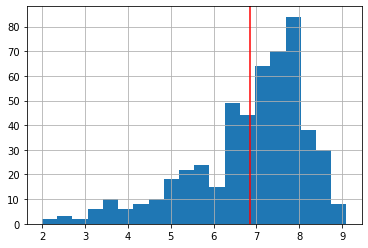

```python
#aux=data_actual.query('Genre=="Action" and User_Score>-1')['User_Score'].mean()
aux=data_actual.query('Genre=="Action"')['User_Score'].mean()
print_mejorado(f"El promedio de las calificaciones de Action es: {aux:.2}",20)
#data_actual.query('Genre=="Action" and User_Score>-1')['User_Score'].hist(bins=20)
data_actual.query('Genre=="Action"')['User_Score'].hist(bins=20)
plt.axvline(x=aux, color='r')
```

El promedio de las calificaciones de Sports es: 5.5

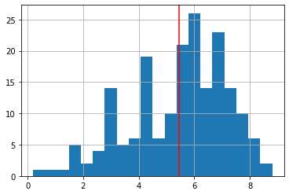

```python
#aux=data_actual.query('Genre=="Sports" and User_Score>-1')['User_Score'].mean()
aux=data_actual.query('Genre=="Sports"')['User_Score'].mean()
print_mejorado(f"El promedio de las calificaciones de Sports es: {aux:.2}",20)
#data_actual.query('Genre=="Sports" and User_Score>-1')['User_Score'].hist(bins=20)
data_actual.query('Genre=="Sports"')['User_Score'].hist(bins=20)
plt.axvline(x=aux, color='r')
```

Ambas distribuciones parecen tener un sesgo hacia la izquierda.

Definimos nuestros muestras:

```python
calificaciones_action = data_actual.query('Genre=="Action" and User_Score.notnull()')['User_Score']
calificaciones_sports = data_actual.query('Genre=="Sports" and User_Score.notnull()')['User_Score']
```

Aplicamos el test de Shapiro para evaluar la normalidad de los datos.

```python
stat, p = st.shapiro(calificaciones_action)
if p > 0.05: print_mejorado("Las calificaciones de Action tienen una distribución normal",20)
else: print_mejorado("Las calificaciones de Action NO tienen una distribución normal",20)

stat, p = st.shapiro(calificaciones_sports)
if p > 0.05: print_mejorado("Las calificaciones de Sports tienen una distribución normal",20)
else: print_mejorado("Las calificaciones de Sports NO tienen una distribución normal",20)
```

Las calificaciones de Action NO tienen una distribución normal

Las calificaciones de Sports NO tienen una distribución normal

Aplicamos el test de Levene para evaluar sin las varianzas de nuestras muestras son distintas.

```python
# Test de Levene para verificar si las varianzas son iguales
stat, p = st.levene(calificaciones_action, calificaciones_sports)

if p > 0.05:
    print_mejorado("Las varianzas son iguales",20)
else:
    print_mejorado("Las varianzas son diferentes",20)
```

Las varianzas son diferentes

Procedemos a probar nuestras hipotesis. Dado que el test de Levene arrojó que nuestras varianzas son distintas, en `st.ttest_ind` usaré el atributo `equal_var=False`.

```python
# Prueba las hipótesis
#La hipotesis nula es que las calificaciones promedio para los géneros de acción y deportes son las mismas.
#La hipotesis alterna es que las calificaciones promedio para los géneros de acción y deportes son las mismas.

#calficaciones del genero Action (sin contar las calificaciones ausentes)
#calificaciones_action = data_actual.query('Genre=="Action" and User_Score>-1')['User_Score']

#calificaciones de la plataforma PC (sin contar las calificaciones ausentes)
#calificaciones_sports = data_actual.query('Genre=="Sports" and User_Score>-1')['User_Score']



#establecemos un nivel crítico de significación estadística (5%)
alpha = 0.05

# Probamos la hipótesis de que las medias de las ventas de los dos plataformas son iguales
#nota: La varianza es diferente para ambos grupos
results = st.ttest_ind(calificaciones_action, calificaciones_sports, equal_var=False)


print('p-value:', results.pvalue)

if (results.pvalue < alpha): # tu código: compara los valores p obtenidos con el nivel de significación estadística
    print_mejorado("Rechazamos la hipótesis nula",20)
    print_mejorado("Las calificaciones promedio para ambos géneros es distinta",24)
else:
    print_mejorado("No rechazamos la hipótesis nula",20)
    print_mejorado("Las calificaciones promedio para ambos géneros es igual",24)
```

```
p-value: 4.105960298744514e-20
```

Rechazamos la hipótesis nula

Las calificaciones promedio para ambos géneros es distinta

## Conclusiones

**Para el periodo analizado (2012-2016)**

- Las plataformas mas relevantes en relación al número de ventas fueron "PS4", "PS3", "X360", "3DS", "XOne" y "WiiU".
- Las menos relevantes fueron las plataformas "PSP", "DS" y "Wii".
- En el 2012 las plataformas mas populares eran PS3, X360, seguida de la portatil 3DS.
- En el 2016 las plataformas con mayor relevancia son PS4, XOne y 3DS.

**Ventas (2012-2016)**

- El ingreso promedio para la PS4 es de 800.000 dolares con ingresos tipicos entre 10.000 y 1.750.000 dolares app.
- El ingreso promedio la XOne es de 645.000 dolares con ingresos tipicos entre 10.000 y 1.600.000 dolares app.
- El ingreso promedio para la 3DS es de 490.000 dolares con ingresos típicos entre 10.000 y 750.000 dolares app.

**Correlaciones ventas vs/Reseñas**

- Existe una correlación directa entre la calificación de la crítica y las ventas del titulo.

**Ganancias por género (2012-2016)**

- Los géneros mas populares son Action, Shooting, Role-Playing y Sports.
- El género de un juego no siempre garantiza el exito o fracaso del mismo.

**Diferencias por región**  
*Plataformas*

- En el 2012 en Norteamerica y Europa las plataformas mas populares eran PS3, X360 y 3DS.
- En el 2016 en Norteamerica y Europa las plataformas mas populares eran PS4 y XOne.
- En Japón la plataforma mas popular en los últimos 5 años es 3DS.
- En 2016 en Japón las consolas mas populares despues de 3DS son PS4 y PSV.

*Géneros*

- En Norteamerica y Europa el género mas popular es Action, seguido por Shotter, luego Sports y Role-Playing.
- Para Norteamerica el quinto género mas popular es Misc.
- Para Europa el quinto género mas popular es Racing.
- En Japón el género Role-Playing es el mas popular, seguido del género Action.

*Clasificacion ESRB*

- En Norteamerica y Europa los juegos populares son clasificación M (Mature). Luego E, T y E+10.
- En Japón los juegos populares son clasificación E (Everyone). Luego T, M y E+10.

**Hipotesis**

- Las calificaciones promedio de los usuarios para los juegos de las plataformas XOne y PC son similares.
- Las calificaciones promedio de los usuarios para los juegos de los géneros de Action y Sports son diferentes.